# Analisis Pola Rental Film

## Analisis Kategori Film

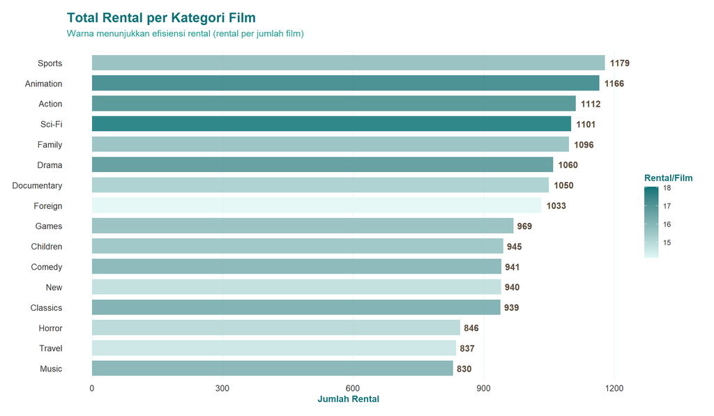

```r
df_kat_plot <- df_kategori %>%
  arrange(desc(total_rentals)) %>%
  mutate(category = fct_reorder(category, total_rentals))

ggplot(df_kat_plot, aes(x = total_rentals, y = category, fill = rental_per_film)) +
  geom_col(width = 0.75, alpha = 0.85) +
  geom_text(aes(label = total_rentals), hjust = -0.25, size = 3.8, fontface = "bold", color = "#5a4a3a") +
  scale_fill_gradient(low = "#e0f7f5", high = "#0d7377", name = "Rental/Film") +
  labs(title = "Total Rental per Kategori Film",
       subtitle = "Warna menunjukkan efisiensi rental (rental per jumlah film)",
       x = "Jumlah Rental",
       y = NULL) +
  theme_minimal() +
  theme(
    plot.title = element_text(size = 16, color = "#0d7377", face = "bold", hjust = 0),
    plot.subtitle = element_text(size = 11, color = "#169b8e", hjust = 0, margin = margin(b = 15)),
    axis.title.x = element_text(size = 11, color = "#0d7377", face = "bold"),
    axis.text.x = element_text(size = 10, color = "#333"),
    axis.text.y = element_text(size = 10, color = "#333"),
    panel.grid.major.x = element_line(color = "#d0f0ed", size = 0.3),
    panel.grid.minor = element_blank(),
    panel.grid.major.y = element_blank(),
    legend.position = "right",
    legend.title = element_text(color = "#0d7377", face = "bold"),
    legend.text = element_text(color = "#333"),
    plot.margin = margin(15, 20, 15, 15)
  )
```

**Tabel Statistik Kategori:**

```r
df_kategori %>%
  kable(col.names = c("Kategori", "Total Rental", "Jumlah Film", "Rental per Film"),
        caption = "Statistik Rental per Kategori Film") %>%
  kable_styling(bootstrap_options = "striped", font_size = 11)
```

Statistik Rental per Kategori Film

| Kategori | Total Rental | Jumlah Film | Rental per Film |
| --- | --- | --- | --- |
| Sports | 1179 | 74 | 15.93 |
| Animation | 1166 | 66 | 17.67 |
| Action | 1112 | 64 | 17.38 |
| Sci-Fi | 1101 | 61 | 18.05 |
| Family | 1096 | 69 | 15.88 |
| Drama | 1060 | 62 | 17.10 |
| Documentary | 1050 | 68 | 15.44 |
| Foreign | 1033 | 73 | 14.15 |
| Games | 969 | 61 | 15.89 |
| Children | 945 | 60 | 15.75 |
| Comedy | 941 | 58 | 16.22 |
| New | 940 | 63 | 14.92 |
| Classics | 939 | 57 | 16.47 |
| Horror | 846 | 56 | 15.11 |
| Travel | 837 | 57 | 14.68 |
| Music | 830 | 51 | 16.27 |

$$\text{Efisiensi Rental} =
\frac{\text{Total Rental per Kategori}}{\text{Jumlah Film}}$$

**Analisis Statistik Kategori:**

```r
# Statistik kategori
kat_mean <- mean(df_kategori$total_rentals)
kat_median <- median(df_kategori$total_rentals)
kat_sd <- sd(df_kategori$total_rentals)

rpf_mean <- mean(df_kategori$rental_per_film)
rpf_max <- max(df_kategori$rental_per_film)
rpf_min <- min(df_kategori$rental_per_film)

# Kategori terbaik dan terburuk
best_cat <- df_kategori %>% slice_max(rental_per_film, n=1)
worst_cat <- df_kategori %>% slice_min(rental_per_film, n=1)
high_rental <- df_kategori %>% slice_max(total_rentals, n=1)

cat("Statistik Kategori Film:\n")
```

```
## Statistik Kategori Film:
```

```r
cat("Total Kategori       :", nrow(df_kategori), "\n")
```

```
## Total Kategori       : 16
```

```r
cat("Rata-rata Rental     :", round(kat_mean, 2), "\n")
```

[output not shown]

```r
cat("Median Rental        :", kat_median, "\n")
```

[output not shown]

```r
cat("Std Dev              :", round(kat_sd, 2), "\n\n")
```

```
## Std Dev              : 113.31
```

```r
cat("Efisiensi (Rental/Film):\n")
```

```
## Efisiensi (Rental/Film):
```

```r
cat("Rata-rata            :", round(rpf_mean, 2), "\n")
```

```
## Rata-rata            : 16.06
```

```r
cat("Maksimum             :", rpf_max, "di kategori", best_cat$category, "\n")
```

```
## Maksimum             : 18.05 di kategori Sci-Fi
```

```r
cat("Minimum              :", rpf_min, "di kategori", worst_cat$category, "\n\n")
```

```
## Minimum              : 14.15 di kategori Foreign
```

```r
cat("Kategori Tertinggi Rental:", high_rental$category, "dengan", high_rental$total_rentals, "rental\n")
```

[output not shown]

**Interpretasi dan Analisis :**

1. **Ada Genre yang Lebih Populer dari Lainnya:** Beberapa jenis film (genre) jauh lebih sering disewa daripada yang lain. Ada genre yang selalu ramai disewa dan ada genre yang jarang disewa. Ini menunjukkan bahwa pelanggan punya pilihan yang jelas terhadap jenis film tertentu.
2. **Efisiensi Film dalam Kategori:** Tidak semua film dalam satu kategori sama populernya. Ada kategori yang mungkin punya banyak film, tapi tidak semua sering disewa. Sebaliknya, ada kategori dengan film lebih sedikit, tetapi setiap film disewa berkali-kali. Untuk kategori dengan film yang sangat populer (setiap film disewa banyak), toko sebaiknya beli lebih banyak copy.
3. **Kategori Populer Harus Dapat Perhatian:** Genre film yang banyak disewa perlu mendapat perhatian khusus. Toko harus menyediakan banyak copy, menampilkan di lokasi yang mudah dilihat, dan terus mengupdate koleksi dengan film-film baru dari genre favorit ini.
4. **Kategori Kurang Populer Butuh Strategi:** Film dari kategori yang jarang disewa masih bisa berhasil jika dipilih dengan baik dan dipromosikan dengan hati-hati. Toko bisa coba memberikan diskon khusus atau menampilkan rekomendasi untuk kategori ini agar pelanggan mau mencoba.
5. **Jangan Membeli Film Asal-asalan:** Daripada membeli bebagai macam film untuk semua kategori, lebih baik fokus pada kategori populer dan pilih film-film berkualitas untuk kategori yang kurang populer. Ini akan menghemat uang dan mengurangi risiko film tidak laku.
6. **Tawarkan Variasi untuk Pelanggan Setia:** Pelanggan yang sering menyewa dari kategori populer bisa didorong untuk mencoba kategori lain dengan memberikan rekomendasi atau diskon bundling. Misalnya, jika pelanggan sering sewa action, toko bisa tawarkan diskon ketika mereka menyewa adventure film juga.

# Kesimpulan dan Rekomendasi

Dari analisis data rental film, kita dapat menyimpulkan kedalam beberapa poin berikut :

**Rekomendasi Strategis:**

**1. Manajemen Inventory** Tingkatkan jumlah copy untuk film-film top 15 yang paling populer, minimal 3-5 copy per film untuk mengurangi risiko kehabisan stok. Implementasikan sistem booking atau reservation untuk customer, sehingga ketika film sedang penuh, customer bisa memesan untuk rental di kemudian hari. Prioritaskan budget pembelian film baru untuk kategori dengan rental/film ratio tinggi, karena setiap film dalam kategori ini memiliki demand yang tinggi. Lakukan review berkala terhadap koleksi film dan lepaskan film dengan performa sangat rendah untuk memberikan ruang bagi film-film baru yang lebih sesuai preferensi customer.

**2. Optimisasi Kategori** Distribusikan 60-70% dari total stok untuk kategori dengan performa tinggi, sementara kategori underperformer mendapat bagian lebih kecil. Untuk kategori yang kurang populer, lebih baik pilih film berkualitas tinggi daripada jumlah banyak dengan kualitas rendah. Secara berkala evaluasi performa setiap kategori dan pertimbangkan untuk mengurangi atau menghilangkan kategori yang konsisten underperform.

**3. Strategi Display dan Promosi** Tempatkan film-film top pada lokasi paling strategis di toko seperti entrance dan checkout counter. Buat bundling promosi yang menggabungkan film populer dengan film dari kategori yang kurang populer, sehingga bisa meningkatkan exposure kategori tersebut. Implementasikan loyalty program yang memberikan benefit tambahan untuk customer yang sering menyewa dari kategori populer.

**4. Monitoring & Evaluation** Lakukan monitoring berkala terhadap performa rental setiap minggu atau sebulan sekali untuk mendeteksi tren perubahan. Update inventory strategy berdasarkan tren baru yang muncul agar selalu relevan dengan pilihan customer. Track ROI dari setiap film yang dibeli untuk membuat keputusan pembelian yang lebih berbasis data di masa depan.